# Prévision spam

## Prévision des mails spam / non-spam en utilisant la régression logistique

Pour ce projet nous allons prédire les mails spam et non spam. Afin de faire cela, nous disposons d'une base de données 'spam.csv'. Nous commençons par déterminer la variable dépendante et son type (binaire ou pas). Puis nous divisons l'ensemble des données en sous-ensembles de test et train. Nous utilisons la 'backward regression' pour déterminer les variables que nous allons prendre en compte lors de la régression logistique.

```python
%%capture
import os
os.getcwd()
```

On importe les packages

```python
import pandas as pd
from sklearn.linear_model import LogisticRegression
from sklearn.preprocessing import StandardScaler
from sklearn.model_selection import train_test_split
from sklearn.metrics import confusion_matrix
import statsmodels.api as sm
import seaborn as sns
import numpy as np
sns.set()
```

Chargement des données

```python
spam = pd.read_csv("spam.csv",sep=',')
spam.head()
```

|  | make | address | all | num3d | our | over | remove | internet | order | mail | ... | charSemicolon | charRoundbracket | charSquarebracket | charExclamation | charDollar | charHash | capitalAve | capitalLong | capitalTotal | type |
| --- | --- | --- | --- | --- | --- | --- | --- | --- | --- | --- | --- | --- | --- | --- | --- | --- | --- | --- | --- | --- | --- |
| 0 | 0.00 | 0.64 | 0.64 | 0.0 | 0.32 | 0.00 | 0.00 | 0.00 | 0.00 | 0.00 | ... | 0.00 | 0.000 | 0.0 | 0.778 | 0.000 | 0.000 | 3.756 | 61 | 278 | spam |
| 1 | 0.21 | 0.28 | 0.50 | 0.0 | 0.14 | 0.28 | 0.21 | 0.07 | 0.00 | 0.94 | ... | 0.00 | 0.132 | 0.0 | 0.372 | 0.180 | 0.048 | 5.114 | 101 | 1028 | spam |
| 2 | 0.06 | 0.00 | 0.71 | 0.0 | 1.23 | 0.19 | 0.19 | 0.12 | 0.64 | 0.25 | ... | 0.01 | 0.143 | 0.0 | 0.276 | 0.184 | 0.010 | 9.821 | 485 | 2259 | spam |
| 3 | 0.00 | 0.00 | 0.00 | 0.0 | 0.63 | 0.00 | 0.31 | 0.63 | 0.31 | 0.63 | ... | 0.00 | 0.137 | 0.0 | 0.137 | 0.000 | 0.000 | 3.537 | 40 | 191 | spam |
| 4 | 0.00 | 0.00 | 0.00 | 0.0 | 0.63 | 0.00 | 0.31 | 0.63 | 0.31 | 0.63 | ... | 0.00 | 0.135 | 0.0 | 0.135 | 0.000 | 0.000 | 3.537 | 40 | 191 | spam |

5 rows × 58 columns

Visualisation du type de mail

```python
spam.type.unique()
```

```
array(['spam', 'nonspam'], dtype=object)
```

histogram spam et non spam

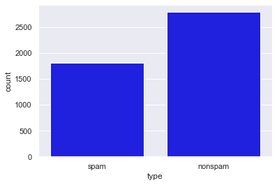

```python
sns.countplot(spam['type'], color='blue')
```

Transformation du statut de spam en binaire

```python
typestatus = {'spam': 1,'nonspam': 0}
spam.type = [typestatus.get(item) for item in spam.type]
```

Vérification de la conversion du type spam et non spam

```python
spam.type.unique()
```

```
array([1, 0], dtype=int64)
```

Définition des données X et de la variable Y

```python
X =spam.drop('type',axis=1)
Y =spam['type']
pd.value_counts(pd.Series(Y))
```

```
0    2788
1    1813
Name: type, dtype: int64
```

Division de l'ensemble des données en sous-ensembles de test et train

```python
X_train, X_test, Y_train, Y_test = train_test_split(X, Y, test_size=0.25, random_state=42)
```

La régression backward

```python
def backward_regression(X, y,
                           initial_list=[],
                           threshold_in=0.01,
                           threshold_out = 0.05,
                           verbose=True):
    included=list(X.columns)
    while True:
        changed=False
        model = sm.Logit(y, sm.add_constant(pd.DataFrame(X[included]))).fit()
        # use all coefs except intercept
        pvalues = model.pvalues.iloc[1:]
        worst_pval = pvalues.max() # null if pvalues is empty
        if worst_pval > threshold_out:
            changed=True
            worst_feature = pvalues.idxmax()
            included.remove(worst_feature)
            if verbose:
                print('Drop {:20} with p-value {:.6}'.format(worst_feature, worst_pval))
        if not changed:
            break
    return included
```

Stockage des résultats de la régression backward

```python
result=backward_regression(X_train, Y_train)
result
```

```
Optimization terminated successfully.
         Current function value: 0.193769
         Iterations 15
Drop email                with p-value 0.875072
```

```
Optimization terminated successfully.
         Current function value: 0.193773
         Iterations 16
Drop num1999              with p-value 0.757217
Optimization terminated successfully.
         Current function value: 0.193786
         Iterations 16
```

```
Drop people               with p-value 0.741904
```

```
Optimization terminated successfully.
         Current function value: 0.193802
         Iterations 16
Drop mail                 with p-value 0.699348
```

```
Optimization terminated successfully.
         Current function value: 0.193824
         Iterations 15
Drop charSquarebracket    with p-value 0.546146
Optimization terminated successfully.
         Current function value: 0.193897
         Iterations 16
Drop all                  with p-value 0.516157
Optimization terminated successfully.
         Current function value: 0.193957
         Iterations 16
```

```
Drop num857               with p-value 0.493241
Optimization terminated successfully.
         Current function value: 0.194036
         Iterations 16
```

```
Drop num415               with p-value 0.474232
Optimization terminated successfully.
         Current function value: 0.194127
         Iterations 15
```

```
Drop report               with p-value 0.466331
Optimization terminated successfully.
         Current function value: 0.194200
         Iterations 16
Drop font                 with p-value 0.457149
```

```
Optimization terminated successfully.
         Current function value: 0.194291
         Iterations 15
Drop will                 with p-value 0.369406
Optimization terminated successfully.
         Current function value: 0.194413
         Iterations 16
Drop charRoundbracket     with p-value 0.297077
```

```
Optimization terminated successfully.
         Current function value: 0.194595
         Iterations 16
Drop num3d                with p-value 0.262798
Optimization terminated successfully.
         Current function value: 0.195393
         Iterations 15
Drop parts                with p-value 0.230907
```

```
Optimization terminated successfully.
         Current function value: 0.195912
         Iterations 15
Drop make                 with p-value 0.212858
Optimization terminated successfully.
         Current function value: 0.196157
         Iterations 16
Drop lab                  with p-value 0.183115
```

```
Optimization terminated successfully.
         Current function value: 0.196822
         Iterations 16
Drop labs                 with p-value 0.141105
Optimization terminated successfully.
         Current function value: 0.197267
         Iterations 15
Drop original             with p-value 0.154988
```

```
Optimization terminated successfully.
         Current function value: 0.197844
         Iterations 15
Drop address              with p-value 0.136929
Optimization terminated successfully.
         Current function value: 0.198332
         Iterations 15
Drop direct               with p-value 0.126687
```

```
Optimization terminated successfully.
         Current function value: 0.198758
         Iterations 15
Drop table                with p-value 0.158747
Optimization terminated successfully.
         Current function value: 0.199204
         Iterations 15
Drop telnet               with p-value 0.11652
```

```
Optimization terminated successfully.
         Current function value: 0.199413
         Iterations 15
Drop order                with p-value 0.111967
Optimization terminated successfully.
         Current function value: 0.199812
         Iterations 15
Drop num85                with p-value 0.0995083
```

```
Optimization terminated successfully.
         Current function value: 0.200420
         Iterations 15
Drop credit               with p-value 0.0820782
Optimization terminated successfully.
         Current function value: 0.202007
         Iterations 15
Drop hpl                  with p-value 0.0658488
Optimization terminated successfully.
         Current function value: 0.202619
         Iterations 15
Drop num650               with p-value 0.0560872
Optimization terminated successfully.
         Current function value: 0.203222
         Iterations 15
```

```
['our',
 'over',
 'remove',
 'internet',
 'receive',
 'addresses',
 'free',
 'business',
 'you',
 'your',
 'num000',
 'money',
 'hp',
 'george',
 'data',
 'technology',
 'pm',
 'cs',
 'meeting',
 'project',
 're',
 'edu',
 'conference',
 'charSemicolon',
 'charExclamation',
 'charDollar',
 'charHash',
 'capitalAve',
 'capitalLong',
 'capitalTotal']
```

Nouveau data frame avec les variables données de la méthode backward

```python
X_train_backward =X_train[result]
```

```python
X_train_backward= X_train_backward.assign(Intercept=1)
```

Utilisons seulement les variables jugées significatives par la régression backward

```python
X_1 = X_train_backward[X_train_backward.columns[0:30]].values
y_1 = Y_train.values
```

```python
scaler = StandardScaler()
Xstan = scaler.fit_transform(X_1)
```

Nouveau data frame avec les données standardisées

```python
dataStan=pd.DataFrame(data = Xstan, columns = X_train_backward.columns[0:30])
dataStan['type']=y_1
dataStan.head()
```

|  | our | over | remove | internet | receive | addresses | free | business | you | your | ... | edu | conference | charSemicolon | charExclamation | charDollar | charHash | capitalAve | capitalLong | capitalTotal | type |
| --- | --- | --- | --- | --- | --- | --- | --- | --- | --- | --- | --- | --- | --- | --- | --- | --- | --- | --- | --- | --- | --- |
| 0 | -0.452600 | -0.351789 | 3.075692 | -0.256473 | -0.295013 | -0.189084 | 1.091876 | -0.316664 | -0.930399 | -0.661572 | ... | -0.210482 | -0.11541 | -0.157794 | 1.903839 | -0.319446 | -0.122042 | -0.116491 | -0.211753 | -0.419091 | 1 |
| 1 | -0.452600 | -0.351789 | -0.297267 | -0.256473 | -0.295013 | -0.189084 | -0.292027 | -0.316664 | -0.364652 | -0.389776 | ... | -0.210482 | -0.11541 | -0.157794 | -0.306681 | -0.319446 | -0.122042 | -0.108140 | -0.188413 | -0.359606 | 0 |
| 2 | 0.599145 | -0.351789 | -0.297267 | 1.480316 | -0.295013 | -0.189084 | -0.292027 | 6.160294 | -0.134992 | 2.278761 | ... | -0.210482 | -0.11541 | -0.157794 | 0.754688 | -0.319446 | -0.122042 | 0.219937 | 0.297057 | -0.109416 | 1 |
| 3 | -0.319280 | -0.200999 | -0.297267 | -0.256473 | -0.096244 | -0.189084 | -0.134509 | 0.115133 | -0.543898 | -0.134453 | ... | -0.210482 | -0.11541 | -0.098953 | -0.290720 | -0.132588 | -0.102186 | -0.093392 | -0.127729 | 1.650660 | 0 |
| 4 | -0.452600 | -0.351789 | -0.297267 | -0.256473 | -0.295013 | -0.189084 | -0.292027 | -0.316664 | 2.122395 | -0.661572 | ... | -0.210482 | -0.11541 | -0.157794 | -0.306681 | -0.319446 | -0.122042 | -0.112678 | -0.239761 | -0.483826 | 0 |

5 rows × 31 columns

La régression logistique

```python
softReg = LogisticRegression(solver = 'lbfgs')
```

```python
softReg.fit(Xstan,y_1)
softReg.intercept_,softReg.coef_
```

```
(array([-2.45908465]),
 array([[ 0.42626776,  0.14780967,  0.88873313,  0.20179481, -0.10824399,
          0.40235028,  0.95383117,  0.38000726,  0.22847799,  0.28990006,
          0.9053097 ,  0.19384363, -3.54217964, -4.63145485, -0.69958104,
          0.48035419, -0.44249174, -1.60302233, -1.40401803, -1.45897028,
         -0.80868513, -1.11189663, -1.14582034, -0.19412005,  0.25515462,
          1.22354733,  1.23173613, -0.18668035,  0.84445095,  0.71386171]]))
```

Prévision sur les données train

```python
yhat = softReg.predict(Xstan)
dataStan['predict_1'] = yhat
dataStan.head()
```

|  | our | over | remove | internet | receive | addresses | free | business | you | your | ... | conference | charSemicolon | charExclamation | charDollar | charHash | capitalAve | capitalLong | capitalTotal | type | predict_1 |
| --- | --- | --- | --- | --- | --- | --- | --- | --- | --- | --- | --- | --- | --- | --- | --- | --- | --- | --- | --- | --- | --- |
| 0 | -0.452600 | -0.351789 | 3.075692 | -0.256473 | -0.295013 | -0.189084 | 1.091876 | -0.316664 | -0.930399 | -0.661572 | ... | -0.11541 | -0.157794 | 1.903839 | -0.319446 | -0.122042 | -0.116491 | -0.211753 | -0.419091 | 1 | 1 |
| 1 | -0.452600 | -0.351789 | -0.297267 | -0.256473 | -0.295013 | -0.189084 | -0.292027 | -0.316664 | -0.364652 | -0.389776 | ... | -0.11541 | -0.157794 | -0.306681 | -0.319446 | -0.122042 | -0.108140 | -0.188413 | -0.359606 | 0 | 0 |
| 2 | 0.599145 | -0.351789 | -0.297267 | 1.480316 | -0.295013 | -0.189084 | -0.292027 | 6.160294 | -0.134992 | 2.278761 | ... | -0.11541 | -0.157794 | 0.754688 | -0.319446 | -0.122042 | 0.219937 | 0.297057 | -0.109416 | 1 | 1 |
| 3 | -0.319280 | -0.200999 | -0.297267 | -0.256473 | -0.096244 | -0.189084 | -0.134509 | 0.115133 | -0.543898 | -0.134453 | ... | -0.11541 | -0.098953 | -0.290720 | -0.132588 | -0.102186 | -0.093392 | -0.127729 | 1.650660 | 0 | 0 |
| 4 | -0.452600 | -0.351789 | -0.297267 | -0.256473 | -0.295013 | -0.189084 | -0.292027 | -0.316664 | 2.122395 | -0.661572 | ... | -0.11541 | -0.157794 | -0.306681 | -0.319446 | -0.122042 | -0.112678 | -0.239761 | -0.483826 | 0 | 0 |

5 rows × 32 columns

Matrice de confusion

```python
C1 = confusion_matrix(dataStan['type'].values,yhat)
confusionMatrix_1 = pd.DataFrame(data = C1, index=['nonspam(0), true','spam(1), true'], columns = ['ns(0), predicted','s(1), predicted'])
confusionMatrix_1.loc['sum'] = confusionMatrix_1.sum()
confusionMatrix_1['sum'] = confusionMatrix_1.sum(axis=1)
confusionMatrix_1
```

|  | ns(0), predicted | s(1), predicted | sum |
| --- | --- | --- | --- |
| nonspam(0), true | 2014 | 98 | 2112 |
| spam(1), true | 166 | 1172 | 1338 |
| sum | 2180 | 1270 | 3450 |

Prédiction sur les données test On prend en compte seulement les 30 variables donnée par la régression backward pour nos données test.

```python
X_test_N=X_test[result]

X_2 = X_test[X_test_N.columns[0:30]].values

y_2 = Y_test.values
```

Standardisation des données

```python
scaler = StandardScaler()
Xstan2 = scaler.fit_transform(X_2)
```

Nouveau data frame avec les données standardisées

```python
dataStan2=pd.DataFrame(data = Xstan2, columns = X_test_N.columns[0:30])
dataStan2['type']=y_2
dataStan2.head()
```

|  | our | over | remove | internet | receive | addresses | free | business | you | your | ... | edu | conference | charSemicolon | charExclamation | charDollar | charHash | capitalAve | capitalLong | capitalTotal | type |
| --- | --- | --- | --- | --- | --- | --- | --- | --- | --- | --- | --- | --- | --- | --- | --- | --- | --- | --- | --- | --- | --- |
| 0 | -0.500332 | -0.348074 | -0.284911 | -0.283033 | -0.302377 | -0.193275 | -0.363204 | -0.334323 | -0.954347 | -0.715426 | ... | -0.167331 | -0.101357 | -0.160711 | -0.453373 | -0.282488 | -0.079336 | -0.143174 | -0.399167 | -0.416486 | 0 |
| 1 | -0.500332 | -0.348074 | -0.284911 | -0.283033 | -0.302377 | -0.193275 | 2.032819 | -0.334323 | -0.134901 | -0.715426 | ... | 1.206033 | -0.101357 | -0.160711 | -0.453373 | -0.282488 | -0.079336 | -0.142164 | -0.390782 | -0.375056 | 0 |
| 2 | -0.500332 | -0.348074 | -0.284911 | 0.911335 | -0.302377 | -0.193275 | -0.363204 | -0.334323 | 0.352183 | -0.715426 | ... | -0.167331 | -0.101357 | -0.160711 | -0.453373 | -0.282488 | -0.079336 | -0.133079 | -0.348858 | -0.273625 | 0 |
| 3 | -0.500332 | -0.348074 | -0.284911 | -0.283033 | -0.302377 | -0.193275 | -0.363204 | -0.334323 | -0.954347 | -0.715426 | ... | -0.167331 | -0.101357 | -0.160711 | -0.453373 | 0.081643 | -0.079336 | -0.031254 | 0.087156 | -0.219337 | 1 |
| 4 | -0.500332 | -0.348074 | -0.284911 | -0.283033 | -0.302377 | -0.193275 | -0.363204 | -0.334323 | 0.930952 | -0.715426 | ... | 0.091976 | -0.101357 | -0.160711 | -0.453373 | -0.282488 | -0.079336 | -0.119673 | -0.306933 | -0.293625 | 0 |

5 rows × 31 columns

Prédiction sur les données test

```python
yhat = softReg.predict(Xstan2)
dataStan2['predict_2'] = yhat
dataStan2.head()
```

|  | our | over | remove | internet | receive | addresses | free | business | you | your | ... | conference | charSemicolon | charExclamation | charDollar | charHash | capitalAve | capitalLong | capitalTotal | type | predict_2 |
| --- | --- | --- | --- | --- | --- | --- | --- | --- | --- | --- | --- | --- | --- | --- | --- | --- | --- | --- | --- | --- | --- |
| 0 | -0.500332 | -0.348074 | -0.284911 | -0.283033 | -0.302377 | -0.193275 | -0.363204 | -0.334323 | -0.954347 | -0.715426 | ... | -0.101357 | -0.160711 | -0.453373 | -0.282488 | -0.079336 | -0.143174 | -0.399167 | -0.416486 | 0 | 0 |
| 1 | -0.500332 | -0.348074 | -0.284911 | -0.283033 | -0.302377 | -0.193275 | 2.032819 | -0.334323 | -0.134901 | -0.715426 | ... | -0.101357 | -0.160711 | -0.453373 | -0.282488 | -0.079336 | -0.142164 | -0.390782 | -0.375056 | 0 | 0 |
| 2 | -0.500332 | -0.348074 | -0.284911 | 0.911335 | -0.302377 | -0.193275 | -0.363204 | -0.334323 | 0.352183 | -0.715426 | ... | -0.101357 | -0.160711 | -0.453373 | -0.282488 | -0.079336 | -0.133079 | -0.348858 | -0.273625 | 0 | 0 |
| 3 | -0.500332 | -0.348074 | -0.284911 | -0.283033 | -0.302377 | -0.193275 | -0.363204 | -0.334323 | -0.954347 | -0.715426 | ... | -0.101357 | -0.160711 | -0.453373 | 0.081643 | -0.079336 | -0.031254 | 0.087156 | -0.219337 | 1 | 1 |
| 4 | -0.500332 | -0.348074 | -0.284911 | -0.283033 | -0.302377 | -0.193275 | -0.363204 | -0.334323 | 0.930952 | -0.715426 | ... | -0.101357 | -0.160711 | -0.453373 | -0.282488 | -0.079336 | -0.119673 | -0.306933 | -0.293625 | 0 | 0 |

5 rows × 32 columns

Matrice de confusion

```python
C2 = confusion_matrix(dataStan2['type'].values,yhat)
confusionMatrix_2 = pd.DataFrame(data = C2, index=['nonspam(0), true','spam(1), true'], columns = ['ns(0), predicted','s(1), predicted'])
confusionMatrix_2.loc['sum'] = confusionMatrix_2.sum()
confusionMatrix_2['sum'] = confusionMatrix_2.sum(axis=1)
confusionMatrix_2
```

|  | ns(0), predicted | s(1), predicted | sum |
| --- | --- | --- | --- |
| nonspam(0), true | 651 | 25 | 676 |
| spam(1), true | 64 | 411 | 475 |
| sum | 715 | 436 | 1151 |

Afin d'évaluer la performance de notre modèle, on calcule l'accuracy, la précision, la sensibilité et la spécificité.

Accuracy de la matrice de confusion 1 (sur les données train): 0.9234782608695652

Accuracy de la matrice de confusion 2 (sur les données test): 0.9226759339704604

Précision de la matrice de confusion 1 (sur les données train): 0.9228346456692913

Précision de la matrice de confusion 2 (sur les données test): 0.9426605504587156

Sensibilité de la matrice de confusion 1 (sur les données train): 0.8759342301943199

Sensibilité de la matrice de confusion 2 (sur les données test): 0.8652631578947368

Spécificité de la matrice de confusion 2 (sur les données test): 0.9630177514792899

On peut voir que le modèle prédit correctement les données avec 92,3 % d'accuracy sur l'ensemble train et avec 92,2% d'accuracy sur l'ensemble test.